# HW02_Jiuru Lyu

Jiuru Lyu

2022-09-08

Before starting solving the homework questions, I am importing the `gss` data set. The `gss` data set has been stored in the sample work directory as this .Rmd file.

```r
gss <- read.csv('gss.csv')
```

# Question 1

*Create a small random sample of size 1000 from gss data set. (set.seed(1234)), name it “smalldat” and save/export on your current working directory.*

To find exactly how many rows of data am I selecting from, I firstly find the dimension of the `gss` data set.

```r
dim(gss)
```

```
## [1] 53474    14
```

The result shows that there are 53474 rows in total, so I will get 1000 random numbers from 1 to 53474 without replacement and set them to the row numbers of extraction.

```r
set.seed(1234)

smalldat <- gss[sample(1:53474, 1000, replace = FALSE), ]

head(smalldat)
```

```
##           X          region         income        happy age       finrela
## 40784 40784  SOUTH ATLANTIC $10000 - 14999   VERY HAPPY  86 BELOW AVERAGE
## 40854 40854  SOUTH ATLANTIC $25000 OR MORE PRETTY HAPPY  42       AVERAGE
## 41964 41964     NEW ENGLAND $25000 OR MORE   VERY HAPPY  36 ABOVE AVERAGE
## 15241 15241  SOUTH ATLANTIC $20000 - 24999 PRETTY HAPPY  47       AVERAGE
## 33702 33702 W. SOU. CENTRAL        REFUSED   VERY HAPPY  59 ABOVE AVERAGE
## 35716 35716  SOUTH ATLANTIC $10000 - 14999 PRETTY HAPPY  78       AVERAGE
##        marital         degree    health          wrkstat            partyid
## 40784  WIDOWED    HIGH SCHOOL      POOR            OTHER       IND NEAR DEM
## 40854  MARRIED       GRADUATE      <NA> WORKING FULLTIME   NOT STR DEMOCRAT
## 41964  MARRIED       BACHELOR      <NA> WORKING FULLTIME NOT STR REPUBLICAN
## 15241  MARRIED    HIGH SCHOOL      GOOD WORKING FULLTIME       IND NEAR DEM
## 33702 DIVORCED       BACHELOR EXCELLENT WORKING FULLTIME  STRONG REPUBLICAN
## 35716  MARRIED LT HIGH SCHOOL      POOR          RETIRED    STRONG DEMOCRAT
##               polviews    sex year
## 40784     CONSERVATIVE FEMALE 2002
## 40854 SLIGHTLY LIBERAL FEMALE 2002
## 41964     CONSERVATIVE FEMALE 2002
## 15241 SLIGHTLY LIBERAL FEMALE 1984
## 33702 SLIGHTLY LIBERAL   MALE 1998
## 35716         MODERATE   MALE 1998
```

Now, I am saving the data into my working directory.

```r
write.csv(smalldat, 'smalldat.csv')
```

The `smalldat` data set is successfully saved.

# Question 2

*Calculate the average age of `smalldat`.*

To calculate the average, we can use the `mean()` function.

```r
mean(smalldat$age)
```

```
## [1] NA
```

The result is weird: R returns `NA`, indicating either there is a missing value or some data is not numeric. I suspect that there is at least a missing value in our random sample, so I run `is.na()` function to testify if any value is missing in the age column of `smalldat` data set.

```r
is.na(smalldat$age)
```

[output not shown]

[output cut: 69 more lines]

As indicated by the result, there are some missing values in our random sample. That explains why we cannot get a numerical value for the average mean if we do not specify the value of `na.rm` argument in the `mean()` function. To successfully finding the average age and stripping the `NA` values, I run the following code:

```r
mean(smalldat$age, na.rm = TRUE)
```

```
## [1] 45.92771
```

Now the average age is successfully calculated, ignoring the existence of the missing values. The result tells us that the average mean of our random sample is 45.9277108.

# Question 3

*Provide an appropriate plot to investigate the distribution of degree of `smalldat`.*

Before creating the bar plot, I need to create the frequency table for the degree column first.

```r
degree_frequency <- table(smalldat$degree)

degree_frequency
```

```
##
##       BACHELOR       GRADUATE    HIGH SCHOOL JUNIOR COLLEGE LT HIGH SCHOOL
##            138             68            541             45            205
```

Using the `degree_frequency` table, I can now create the bar plot:

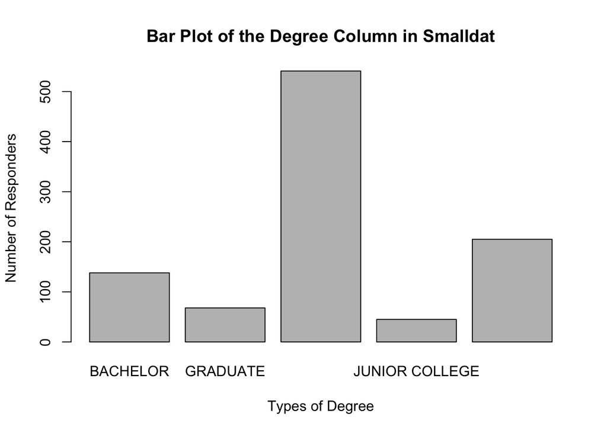

```r
barplot(degree_frequency, main = 'Bar Plot of the Degree Column in Smalldat', xlab = 'Types of Degree', ylab = 'Number of Responders')
```

# Question 4

*Calculate the percentage of married participants with bachelor degree in smalldat (among all married participants, the percentage of them with bachelor degree)?*

```r
prop.table(table(smalldat$degree, smalldat$marital), margin = 2)
```

```
##
##                    DIVORCED    MARRIED NEVER MARRIED  SEPARATED    WIDOWED
##   BACHELOR       0.15037594 0.14177694    0.15763547 0.02941176 0.10309278
##   GRADUATE       0.08270677 0.08128544    0.04926108 0.02941176 0.03092784
##   HIGH SCHOOL    0.49624060 0.54253308    0.60591133 0.58823529 0.45360825
##   JUNIOR COLLEGE 0.05263158 0.04536862    0.05418719 0.02941176 0.02061856
##   LT HIGH SCHOOL 0.21804511 0.18903592    0.13300493 0.32352941 0.39175258
```

As the table indicates, the result of the first row and the the second column indicates the answer we are seeking, which is 0.1417769 (i.e., there are 14.2% of married participants holding a bachelor degree in our random sample).

# Question 5

*Provide an appropriate plot to investigate the relationship between marital status and education status (degree) in smalldat.*

As the martial and degree columns in our data set are all categorical variables, I need to create a bar plot to represent their relationship. In this case, I will not use the marginal proportion table anymore; rather, I will create a frequency table of two variables.

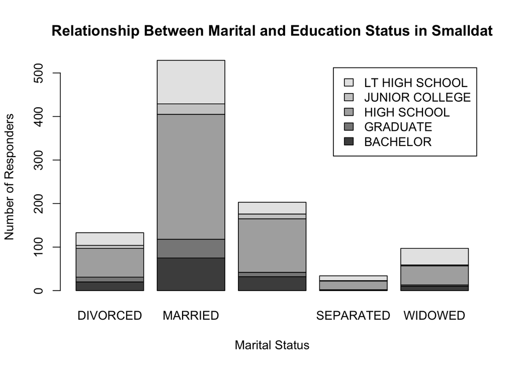

```r
barplot(table(smalldat$degree, smalldat$marital), main = 'Relationship Between Marital and Education Status in Smalldat',  xlab = 'Marital Status', ylab = 'Number of Responders', legend.text = TRUE)
```

```r
legend = c('BACHELOR','GRADUATE',' HIGH SCHOOL', 'JUNIOR COLLEGE', 'LT HIGH SCHOOL' )
```